# Acidentes nas Estradas Brasileiras

Jobenil Júnior e Ivan Arantes

30 de setembro de 2018

## Considerações Gerais

A partir da url:https://www.prf.gov.br/portal/dados-abertos a Polícia Rodoviária Federal disponibiliza bancos de dados relativos a multas e acidentes de trânsito desde 2007. Em primeiro lugar realizamos uma descrição geral dos dados nas estradas Brasileiras e em seguida realizamos um recorte procurando fixar-nos nas principais estradas federais que cortam o estado de Goiás. Procuramos também confrontar as principais datas relativas à mudanças significativas tanto na legislação de trânsico quanto nas condições de trafego (melhoria na estrada), pois acreditamos que estes fatores deveriam/poderiam proporcionar mudanças importântes no comportamento dos motoristas. Empregou-se para realização das análises a linguagem R combinada com RMarkdown no ambiente RStudio.

### 1. Leitura dos dados

```r
prf_2007 <- read.csv2('datatran2007.csv', header = TRUE, sep = ';', dec = '.')
prf_2007$latitude <- 'NA'
prf_2007$longitude <- 'NA'
prf_2007$regional <- 'NA'
prf_2007$delegacia <- 'NA'
prf_2007$uop <- 'NA'

prf_2008 <- read.csv2('datatran2008.csv', header = TRUE, sep = ';', dec = '.')
prf_2008$latitude <- 'NA'
prf_2008$longitude <- 'NA'
prf_2008$regional <- 'NA'
prf_2008$delegacia <- 'NA'
prf_2008$uop <- 'NA'

prf_2009 <- read.csv2('datatran2009.csv', header = TRUE, sep = ';', dec = '.')
prf_2009$latitude <- 'NA'
prf_2009$longitude <- 'NA'
prf_2009$regional <- 'NA'
prf_2009$delegacia <- 'NA'
prf_2009$uop <- 'NA'

prf_2010 <- read.csv2('datatran2010.csv', header = TRUE, sep = ';', dec = '.')
prf_2010$latitude <- 'NA'
prf_2010$longitude <- 'NA'
prf_2010$regional <- 'NA'
prf_2010$delegacia <- 'NA'
prf_2010$uop <- 'NA'

prf_2011 <- read.csv2('datatran2011.csv', header = TRUE, sep = ';', dec = '.')
prf_2011$latitude <- 'NA'
prf_2011$longitude <- 'NA'
prf_2011$regional <- 'NA'
prf_2011$delegacia <- 'NA'
prf_2011$uop <- 'NA'

prf_2012 <- read.csv2('datatran2012.csv', header = TRUE, sep = ';', dec = '.')
prf_2012$latitude <- 'NA'
prf_2012$longitude <- 'NA'
prf_2012$regional <- 'NA'
prf_2012$delegacia <- 'NA'
prf_2012$uop <- 'NA'

prf_2013 <- read.csv2('datatran2013.csv', header = TRUE, sep = ';', dec = '.')
prf_2013$latitude <- 'NA'
prf_2013$longitude <- 'NA'
prf_2013$regional <- 'NA'
prf_2013$delegacia <- 'NA'
prf_2013$uop <- 'NA'

prf_2014 <- read.csv2('datatran2014.csv', header = TRUE, sep = ';', dec = '.')
prf_2014$latitude <- 'NA'
prf_2014$longitude <- 'NA'
prf_2014$regional <- 'NA'
prf_2014$delegacia <- 'NA'
prf_2014$uop <- 'NA'

prf_2015 <- read.csv2('datatran2015.csv', header = TRUE, sep = ';', dec = '.')
prf_2015$latitude <- 'NA'
prf_2015$longitude <- 'NA'
prf_2015$regional <- 'NA'
prf_2015$delegacia <- 'NA'
prf_2015$uop <- 'NA'

prf_2016 <- read.csv2('datatran2016_atual.csv', header = TRUE, sep = ';', dec = ',')
prf_2016$latitude <- 'NA'
prf_2016$longitude <- 'NA'
prf_2016$regional <- 'NA'
prf_2016$delegacia <- 'NA'
prf_2016$uop <- 'NA'

prf_2017 <- read.csv2('datatran2017.csv', header = TRUE, sep = ';', dec = ',')
prf_2018 <- read.csv2('datatran2018.csv', header = TRUE, sep = ';', dec = ',')

prf_acidentes <- rbind(prf_2018, prf_2017, prf_2016, prf_2015, prf_2014, prf_2013, prf_2012, prf_2011, prf_2010, prf_2009, prf_2008, prf_2007)

rm(prf_2018, prf_2017, prf_2016, prf_2015, prf_2014, prf_2013, prf_2012, prf_2011, prf_2010, prf_2009, prf_2008, prf_2007)

#Pacotes a serem utilizados
library(plyr)
library(descr, quietly = TRUE)
library(pander)
```

## 2. Análise Exploratória dos dados

### Tabela 2.1 - Acidentes por dia da semana por ano

```r
prf_acidentes$dia_semana <- revalue(prf_acidentes$dia_semana, c("domingo" = "Domingo", "quarta-feira" = "Quarta", "quinta-feira" = "Quinta", "sábado" = "Sábado", "segunda-feira" = "Segunda", "terça-feira" = "Terça", "sexta-feira" = "Sexta"))

prf_acidentes$dia_semana = factor(prf_acidentes$dia_semana,levels(prf_acidentes$dia_semana)[c(1, 5, 7, 2, 3, 6, 4)])

pander(table(prf_acidentes$dia_semana, prf_acidentes$ano))
```

Table continues below

|  | 2007 | 2008 | 2009 | 2010 | 2011 | 2012 | 2013 | 2014 |
| --- | --- | --- | --- | --- | --- | --- | --- | --- |
| **Domingo** | 20302 | 20671 | 22728 | 26682 | 28352 | 27180 | 26520 | 24248 |
| **Segunda** | 16927 | 18812 | 21877 | 25436 | 26571 | 25504 | 26318 | 23606 |
| **Terça** | 15917 | 18046 | 20287 | 23304 | 24730 | 23331 | 24341 | 21726 |
| **Quarta** | 16282 | 18913 | 20834 | 24443 | 25145 | 24243 | 24831 | 22637 |
| **Quinta** | 17202 | 19041 | 22198 | 25165 | 26390 | 25557 | 25847 | 23300 |
| **Sexta** | 20580 | 23221 | 26077 | 30183 | 30801 | 30828 | 30884 | 27883 |
| **Sábado** | 20465 | 22339 | 24645 | 28256 | 30337 | 27925 | 28007 | 25801 |

|  | 2015 | 2016 | 2017 | 2018 |
| --- | --- | --- | --- | --- |
| **Domingo** | 18614 | 15562 | 14779 | 7344 |
| **Segunda** | 17061 | 12914 | 12170 | 6380 |
| **Terça** | 15398 | 11655 | 10760 | 5945 |
| **Quarta** | 16081 | 12109 | 11018 | 5972 |
| **Quinta** | 16964 | 12774 | 11783 | 6151 |
| **Sexta** | 18996 | 15088 | 13842 | 7287 |
| **Sábado** | 19047 | 16261 | 15166 | 7418 |

### Tabela 2.2 - Acidentes por horário por ano

```r
prf_acidentes$horas <- substr(prf_acidentes$horario, start = 1, stop = 2)

pander(table(prf_acidentes$horas, prf_acidentes$ano))
```

Table continues below

|  | 2007 | 2008 | 2009 | 2010 | 2011 | 2012 | 2013 | 2014 | 2015 |
| --- | --- | --- | --- | --- | --- | --- | --- | --- | --- |
| **00** | 2889 | 2981 | 3128 | 3629 | 3764 | 3355 | 3159 | 2877 | 2282 |
| **01** | 2430 | 2379 | 2494 | 2936 | 3058 | 2758 | 2612 | 2549 | 2096 |
| **02** | 2170 | 2089 | 2221 | 2664 | 2725 | 2462 | 2300 | 2115 | 1793 |
| **03** | 2173 | 2271 | 2402 | 2708 | 2773 | 2536 | 2410 | 2252 | 1869 |
| **04** | 2770 | 2636 | 2847 | 3451 | 3684 | 3411 | 3172 | 3076 | 2450 |
| **05** | 3413 | 3557 | 3828 | 4762 | 4975 | 4664 | 4764 | 4318 | 3415 |
| **06** | 4353 | 5121 | 5647 | 6692 | 7227 | 7021 | 7322 | 6597 | 4894 |
| **07** | 6344 | 7557 | 8389 | 10046 | 10750 | 10614 | 10981 | 10020 | 6872 |
| **08** | 6057 | 7070 | 8033 | 9518 | 10053 | 9814 | 10236 | 9279 | 6275 |
| **09** | 5673 | 6570 | 7531 | 8725 | 9211 | 8843 | 9126 | 8279 | 5665 |
| **10** | 5808 | 6765 | 7541 | 8667 | 9126 | 8859 | 9193 | 8350 | 5727 |
| **11** | 5757 | 6734 | 7715 | 8776 | 9178 | 9061 | 9402 | 8575 | 5714 |
| **12** | 4970 | 5901 | 6775 | 7690 | 8348 | 7939 | 8375 | 7479 | 5131 |
| **13** | 5488 | 6034 | 7112 | 8314 | 8595 | 8238 | 8755 | 8007 | 5524 |
| **14** | 6600 | 7413 | 8571 | 9621 | 10142 | 9582 | 10119 | 9001 | 6482 |
| **15** | 7545 | 8368 | 9395 | 10377 | 11053 | 10826 | 11231 | 10086 | 6993 |
| **16** | 7953 | 9015 | 10232 | 11609 | 11923 | 11739 | 11813 | 10884 | 7554 |
| **17** | 8777 | 9503 | 11031 | 12467 | 13212 | 12892 | 13064 | 11721 | 8370 |
| **18** | 10011 | 10879 | 12379 | 14217 | 14874 | 14330 | 14333 | 12814 | 9096 |
| **19** | 7978 | 8687 | 9708 | 11393 | 11613 | 10974 | 10655 | 9688 | 7268 |
| **20** | 5757 | 6117 | 6726 | 7859 | 8116 | 7760 | 7525 | 6571 | 4965 |
| **21** | 4870 | 5116 | 5862 | 6759 | 7014 | 6478 | 6238 | 5566 | 4483 |
| **22** | 4302 | 4626 | 5095 | 5873 | 6087 | 5718 | 5446 | 5001 | 3919 |
| **23** | 3587 | 3654 | 3984 | 4716 | 4825 | 4694 | 4517 | 4096 | 3324 |

|  | 2016 | 2017 | 2018 |
| --- | --- | --- | --- |
| **00** | 2043 | 2018 | 1011 |
| **01** | 1799 | 1738 | 805 |
| **02** | 1615 | 1544 | 798 |
| **03** | 1675 | 1743 | 776 |
| **04** | 2234 | 2097 | 1015 |
| **05** | 2968 | 2818 | 1390 |
| **06** | 3890 | 3744 | 1983 |
| **07** | 5321 | 4955 | 2700 |
| **08** | 4644 | 4441 | 2268 |
| **09** | 4288 | 3917 | 1967 |
| **10** | 4210 | 3823 | 1896 |
| **11** | 4405 | 3996 | 2067 |
| **12** | 3912 | 3631 | 1913 |
| **13** | 4250 | 3940 | 2125 |
| **14** | 4803 | 4347 | 2296 |
| **15** | 5278 | 4907 | 2457 |
| **16** | 5808 | 5180 | 2542 |
| **17** | 6192 | 5745 | 3034 |
| **18** | 7126 | 6674 | 3784 |
| **19** | 5722 | 5317 | 2938 |
| **20** | 4289 | 3904 | 2142 |
| **21** | 3738 | 3423 | 1751 |
| **22** | 3408 | 3065 | 1539 |
| **23** | 2745 | 2551 | 1300 |

### Tabela 2.3 - Acidentes por UF por ano

```r
pander(table(prf_acidentes$uf, prf_acidentes$ano))
```

Table continues below

|  | 2007 | 2008 | 2009 | 2010 | 2011 | 2012 | 2013 | 2014 |
| --- | --- | --- | --- | --- | --- | --- | --- | --- |
| **AC** | 324 | 353 | 365 | 462 | 518 | 503 | 448 | 457 |
| **AL** | 1604 | 1778 | 1914 | 2277 | 2364 | 2195 | 2376 | 1529 |
| **AM** | 173 | 194 | 199 | 239 | 249 | 218 | 234 | 168 |
| **AP** | 150 | 168 | 161 | 162 | 232 | 241 | 277 | 273 |
| **BA** | 7088 | 7629 | 8208 | 9441 | 10436 | 10281 | 10388 | 10407 |
| **CE** | 2261 | 2691 | 2914 | 3784 | 3825 | 3746 | 4010 | 3791 |
| **DF** | 1139 | 1044 | 1228 | 1299 | 1583 | 1448 | 1535 | 1327 |
| **ES** | 6243 | 6381 | 6746 | 7830 | 7952 | 7719 | 8217 | 7807 |
| **GO** | 5608 | 6455 | 7179 | 8012 | 8061 | 7691 | 7986 | 7125 |
| **MA** | 2112 | 2292 | 2319 | 2605 | 3042 | 3054 | 2956 | 2620 |
| **MG** | 20602 | 22711 | 25079 | 27379 | 27429 | 26783 | 26478 | 21884 |
| **MS** | 2299 | 2635 | 2836 | 3506 | 3507 | 3338 | 3726 | 3428 |
| **MT** | 2638 | 3110 | 3565 | 3744 | 3888 | 4284 | 4572 | 4464 |
| **PA** | 3128 | 3299 | 3413 | 4291 | 4577 | 3842 | 3601 | 3232 |
| **PB** | 2696 | 3325 | 3546 | 3856 | 3990 | 4105 | 4242 | 3659 |
| **PE** | 4765 | 5321 | 5984 | 7358 | 8230 | 7217 | 7612 | 7406 |
| **PI** | 1881 | 2030 | 2216 | 2642 | 2834 | 2768 | 2879 | 2728 |
| **PR** | 7074 | 9684 | 15609 | 20986 | 22189 | 20749 | 19789 | 17178 |
| **RJ** | 11670 | 13436 | 14207 | 16436 | 18279 | 17433 | 17069 | 15404 |
| **RN** | 3067 | 2874 | 3315 | 3935 | 4083 | 3868 | 3975 | 3675 |
| **RO** | 2082 | 2430 | 3094 | 3417 | 3847 | 3578 | 3227 | 2704 |
| **RR** | 458 | 313 | 287 | 228 | 274 | 247 | 341 | 309 |
| **RS** | 11040 | 11254 | 11715 | 14508 | 14996 | 14110 | 15215 | 14432 |
| **SC** | 14587 | 15597 | 17896 | 19445 | 19243 | 18283 | 18988 | 18192 |
| **SE** | 1159 | 1232 | 1201 | 1456 | 1643 | 1672 | 1558 | 1562 |
| **SP** | 11110 | 11981 | 12473 | 13103 | 13965 | 14012 | 13770 | 12139 |
| **TO** | 712 | 823 | 977 | 1068 | 1090 | 1179 | 1279 | 1301 |
| **(null)** | 5 | 3 | 0 | 0 | 0 | 4 | 0 | 0 |

|  | 2015 | 2016 | 2017 | 2018 |
| --- | --- | --- | --- | --- |
| **AC** | 468 | 330 | 300 | 143 |
| **AL** | 1071 | 951 | 904 | 466 |
| **AM** | 131 | 166 | 131 | 85 |
| **AP** | 218 | 198 | 166 | 103 |
| **BA** | 7152 | 5496 | 4683 | 2354 |
| **CE** | 2636 | 2419 | 1952 | 1123 |
| **DF** | 1040 | 1066 | 1093 | 579 |
| **ES** | 4762 | 3230 | 3003 | 1731 |
| **GO** | 6131 | 4968 | 4369 | 2283 |
| **MA** | 2031 | 1513 | 1582 | 839 |
| **MG** | 15540 | 14371 | 12728 | 6096 |
| **MS** | 2818 | 2466 | 1932 | 1057 |
| **MT** | 3759 | 3262 | 3525 | 1842 |
| **PA** | 2318 | 1733 | 1503 | 907 |
| **PB** | 2753 | 1932 | 1852 | 1064 |
| **PE** | 5079 | 3623 | 3440 | 1799 |
| **PI** | 2156 | 1501 | 1539 | 906 |
| **PR** | 12792 | 11032 | 10674 | 5368 |
| **RJ** | 9571 | 6118 | 5964 | 2970 |
| **RN** | 2521 | 1626 | 1456 | 963 |
| **RO** | 2118 | 1715 | 1831 | 1062 |
| **RR** | 319 | 296 | 286 | 154 |
| **RS** | 9869 | 7515 | 6386 | 3043 |
| **SC** | 14037 | 10605 | 10663 | 5775 |
| **SE** | 1097 | 763 | 763 | 373 |
| **SP** | 8901 | 6632 | 6009 | 3024 |
| **TO** | 873 | 836 | 784 | 388 |
| **(null)** | 0 | 0 | 0 | 0 |

```r
prf_acidentes$tipo_acidente <- revalue(prf_acidentes$tipo_acidente, c("Atropelamento de Animal                                                                                                                                                                                 " = "Atropelamento de animal",
                                                                      "Atropelamento de Pedestre                                                                                                                                                                               " = "Atropelamento de pessoa",
                                                                      "Capotamento                                                                                                                                                                                             " = "Capotamento",
                                                                      "Colisão com objeto em movimento                                                                                                                                                                         " = "Colisão com objeto móvel",
                                                                      "Colisão com objeto estático                                                                                                                                                                             " = "Colisão com objeto fixo",
                                                                      "Colisão frontal                                                                                                                                                                                         " = "Colisão frontal",
                                                                      "Colisão lateral                                                                                                                                                                                         " = "Colisão lateral",
                                                                      "Colisão transversal                                                                                                                                                                                     " = "Colisão Transversal",
                                                                      "Colisão traseira                                                                                                                                                                                        " = "Colisão traseira",
                                                                      "Danos eventuais                                                                                                                                                                                         " = "Danos Eventuais",
                                                                      "Derramamento de carga                                                                                                                                                                                   " = "Derramamento de Carga",
                                                                      "Engavetamento                                                                                                                                                                                           " = "Engavetamento",
                                                                      "Incêndio                                                                                                                                                                                                " = "Incêndio" ,
                                                                      "Queda de ocupante de veículo                                                                                                                                                                            " = "Queda de motocicleta / bicicleta / veículo",
                                                                      "Saída de leito carroçavel                                                                                                                                                                               " = "Saída de Pista",
                                                                      "Tombamento                                                                                                                                                                                              " = "Tombamento"  ))
pander(table(prf_acidentes$tipo_acidente, prf_acidentes$ano))
```

Table continues below

|  | 2007 | 2008 | 2009 | 2010 | 2011 | 2012 |
| --- | --- | --- | --- | --- | --- | --- |
| **Atropelamento de animal** | 3563 | 3868 | 3712 | 4251 | 4446 | 4290 |
| **Atropelamento de pessoa** | 3852 | 4465 | 4797 | 5300 | 5090 | 4689 |
| **Capotamento** | 6943 | 7242 | 7694 | 8578 | 8766 | 8415 |
| **Colisão com objeto móvel** | 1517 | 1604 | 1738 | 1961 | 1845 | 1732 |
| **Colisão com objeto fixo** | 8186 | 8732 | 10547 | 11215 | 11384 | 10628 |
| **Colisão frontal** | 4581 | 4742 | 5183 | 6234 | 6589 | 6473 |
| **Colisão lateral** | 20371 | 23679 | 25831 | 30676 | 33216 | 31756 |
| **Colisão Transversal** | 11821 | 13248 | 14901 | 17749 | 19446 | 18720 |
| **Colisão traseira** | 33501 | 37710 | 44130 | 52681 | 55927 | 55286 |
| **Danos Eventuais** | 848 | 1115 | 1219 | 1316 | 1342 | 1101 |
| **Derramamento de Carga** | 854 | 844 | 887 | 1058 | 1071 | 1009 |
| **Engavetamento** | 0 | 0 | 0 | 0 | 0 | 0 |
| **Incêndio** | 456 | 490 | 558 | 674 | 791 | 858 |
| **Queda de motocicleta / bicicleta / veículo** | 3036 | 3664 | 4725 | 5547 | 6133 | 5891 |
| **Saída de leito carroçável** | 0 | 0 | 0 | 0 | 0 | 0 |
| **Tombamento** | 6147 | 5997 | 6162 | 6867 | 6969 | 7242 |
| **Colisão com bicicleta** | 2468 | 2406 | 2231 | 2280 | 2046 | 1714 |
| **Saída de Pista** | 19531 | 21237 | 24331 | 27082 | 27265 | 24764 |

|  | 2013 | 2014 | 2015 | 2016 | 2017 | 2018 |
| --- | --- | --- | --- | --- | --- | --- |
| **Atropelamento de animal** | 4097 | 3174 | 2639 | 2178 | 2011 | 885 |
| **Atropelamento de pessoa** | 4420 | 4152 | 3662 | 3520 | 3627 | 2255 |
| **Capotamento** | 7926 | 7425 | 6551 | 6777 | 5627 | 1962 |
| **Colisão com objeto móvel** | 1672 | 1372 | 912 | 564 | 627 | 273 |
| **Colisão com objeto fixo** | 10061 | 9155 | 7621 | 6679 | 7328 | 3507 |
| **Colisão frontal** | 6797 | 6874 | 5721 | 5251 | 4972 | 3005 |
| **Colisão lateral** | 32256 | 27944 | 17037 | 11215 | 10595 | 5610 |
| **Colisão Transversal** | 18873 | 17940 | 13140 | 10670 | 10209 | 5740 |
| **Colisão traseira** | 56006 | 49396 | 30314 | 19142 | 16139 | 8699 |
| **Danos Eventuais** | 1033 | 839 | 532 | 331 | 363 | 151 |
| **Derramamento de Carga** | 973 | 891 | 603 | 436 | 372 | 179 |
| **Engavetamento** | 0 | 0 | 0 | 0 | 1194 | 661 |
| **Incêndio** | 897 | 870 | 878 | 984 | 1055 | 629 |
| **Queda de motocicleta / bicicleta / veículo** | 5737 | 5783 | 5905 | 6038 | 3615 | 1977 |
| **Saída de leito carroçável** | 0 | 0 | 0 | 0 | 15673 | 7536 |
| **Tombamento** | 6981 | 6808 | 5630 | 5080 | 6111 | 3428 |
| **Colisão com bicicleta** | 1577 | 1346 | 1245 | 1235 | 0 | 0 |
| **Saída de Pista** | 27442 | 25232 | 19771 | 16263 | 0 | 0 |

### Tabela 2.5 - Acidentes por Causa do Acidente por ano

```r
prf_acidentes$causa_acidente <- revalue(prf_acidentes$causa_acidente, c("Agressão Externa                                                                                    " = "Agressão Externa",
                                                                        "Animais na Pista                                                                                    " = "Animais na Pista",
                                                                        "Avarias e/ou desgaste excessivo no pneu                                                             " = "Defeito mecânico em veículo",
                                                                        "Carga excessiva e/ou mal acondicionada                                                              " = "Excesso de carga",
                                                                        "Condutor Dormindo                                                                                   " = "Dormindo",
                                                                        "Defeito Mecânico no Veículo                                                                         " = "Defeito mecânico em veículo",
                                                                        "Defeito na Via                                                                                      " = "Defeito na via",
                                                                        "Deficiência ou não Acionamento do Sistema de Iluminação/Sinalização do Veículo                      " = "Outras",
                                                                        "Desobediência às normas de trânsito pelo condutor                                                   " = "Outras",
                                                                        "Desobediência às normas de trânsito pelo pedestre                                                   " = "Outras",
                                                                        "Falta de Atenção à Condução                                                                         " = "Falta de atenção",
                                                                        "Falta de Atenção do Pedestre                                                                        " = "Falta de atenção",
                                                                        "Fenômenos da Natureza                                                                               " = "Outras",
                                                                        "Ingestão de álcool                                                                                  " = "Ingestão de álcool",
                                                                        "Ingestão de àlcool e/ou substâncias psicoativas pelo pedestre                                       " = "Ingestão de àlcool",
                                                                        "Ingestâo de Substâncias Psicoativas                                                                 " = "Outras",
                                                                        "Mal Sùbito                                                                                          " = "Outras",
                                                                        "Não guardar distância de segurança                                                                  " = "Não guardar distância de segurança",
                                                                        "Objeto estático sobre o leito carroçavel                                                            " = "Outras",
                                                                        "Pista Escorregadia                                                                                  " = "Outras",
                                                                        "Restrição de Visibilidade                                                                           " = "Outras",
                                                                        "Sinalização da via insuficiente ou inadequada                                                       " = "Outras",
                                                                        "Ultrapassagem Indevida                                                                              " = "Ultrapassagem indevida",
                                                                        "Velocidade Incompatível                                                                             " = "Velocidade incompatível"))
pander(table(prf_acidentes$causa_acidente, prf_acidentes$ano))
```

Table continues below

|  | 2007 | 2008 | 2009 | 2010 | 2011 | 2012 |
| --- | --- | --- | --- | --- | --- | --- |
| **Agressão Externa** | 0 | 0 | 0 | 0 | 0 | 0 |
| **Animais na Pista** | 4202 | 4582 | 4205 | 4803 | 5008 | 4834 |
| **Defeito mecânico em veículo** | 5403 | 5858 | 6019 | 6944 | 6981 | 6831 |
| **Excesso de carga** | 0 | 0 | 0 | 0 | 0 | 0 |
| **Dormindo** | 3364 | 3330 | 3335 | 4402 | 4404 | 4625 |
| **Defeito na via** | 2348 | 2191 | 2611 | 2414 | 2790 | 2339 |
| **Outras** | 45968 | 49971 | 55549 | 56871 | 56505 | 49582 |
| **Falta de atenção** | 42256 | 46307 | 52070 | 60879 | 63526 | 61205 |
| **Ingestão de Álcool** | 0 | 0 | 0 | 0 | 0 | 0 |
| **Ingestão de álcool e/ou substâncias psicoativas pelo pedestre** | 0 | 0 | 0 | 0 | 0 | 0 |
| **Ingestão de Substâncias Psicoativas** | 0 | 0 | 0 | 0 | 0 | 0 |
| **Mal Súbito** | 0 | 0 | 0 | 0 | 0 | 0 |
| **Não guardar distância de segurança** | 8137 | 9742 | 11476 | 15588 | 17311 | 18804 |
| **Objeto estático sobre o leito carroçável** | 0 | 0 | 0 | 0 | 0 | 0 |
| **Ultrapassagem indevida** | 2839 | 2994 | 3073 | 3932 | 4249 | 4134 |
| **Velocidade incompatível** | 6011 | 7915 | 10324 | 13673 | 16169 | 16830 |
| **Desobediência Ã sinalização** | 4041 | 4592 | 5171 | 7157 | 7823 | 7789 |
| **Ingestão de álcool** | 3106 | 3561 | 4813 | 6806 | 7559 | 7594 |
| **(null)** | 0 | 0 | 0 | 0 | 1 | 1 |

|  | 2013 | 2014 | 2015 | 2016 | 2017 | 2018 |
| --- | --- | --- | --- | --- | --- | --- |
| **Agressão Externa** | 0 | 0 | 0 | 0 | 2 | 210 |
| **Animais na Pista** | 4768 | 3737 | 3080 | 2605 | 2620 | 1142 |
| **Defeito mecânico em veículo** | 7162 | 6886 | 5729 | 5111 | 6233 | 3230 |
| **Excesso de carga** | 0 | 0 | 0 | 0 | 545 | 254 |
| **Dormindo** | 4827 | 4794 | 4067 | 3763 | 3798 | 1798 |
| **Defeito na via** | 2740 | 2598 | 1994 | 1571 | 1419 | 785 |
| **Outras** | 44055 | 38990 | 29064 | 24668 | 11436 | 7289 |
| **Falta de atenção** | 62854 | 55089 | 36805 | 26451 | 36884 | 18896 |
| **Ingestão de Álcool** | 0 | 0 | 0 | 0 | 6448 | 3379 |
| **Ingestão de álcool e/ou substâncias psicoativas pelo pedestre** | 0 | 0 | 0 | 0 | 0 | 174 |
| **Ingestão de Substâncias Psicoativas** | 0 | 0 | 0 | 0 | 78 | 43 |
| **Mal Súbito** | 0 | 0 | 0 | 0 | 969 | 450 |
| **Não guardar distância de segurança** | 21571 | 19588 | 11402 | 6361 | 5832 | 2898 |
| **Objeto estático sobre o leito carroçável** | 0 | 0 | 0 | 0 | 770 | 392 |
| **Ultrapassagem indevida** | 4472 | 4245 | 2998 | 2327 | 2053 | 922 |
| **Velocidade incompatível** | 18694 | 17716 | 14262 | 12322 | 10431 | 4635 |
| **Desobediência Ã sinalização** | 8078 | 8167 | 6015 | 4852 | 0 | 0 |
| **Ingestão de álcool** | 7527 | 7391 | 6745 | 6332 | 0 | 0 |
| **(null)** | 0 | 0 | 0 | 0 | 0 | 0 |

### Tabela 2.6 - Acidentes por Classificação do Acidente por ano

```r
prf_acidentes$classificacao_acidente[prf_acidentes$classificacao_acidente == ""] <- "Ignorado"
prf_acidentes$classificacao_acidente[prf_acidentes$classificacao_acidente == "(null)"] <- "Ignorado"
tabela <- table(prf_acidentes$classificacao_acidente, prf_acidentes$ano)
tabela <- tabela[c(1:3,5),]
row.names(tabela) <- c("Com Vítimas Fatais", "Com Vítimas Feridas", "Sem Vítimas", "Ignorado")

pander(tabela)
```

Table continues below

|  | 2007 | 2008 | 2009 | 2010 | 2011 | 2012 |
| --- | --- | --- | --- | --- | --- | --- |
| **Com Vítimas Fatais** | 5440 | 5592 | 5945 | 7083 | 7158 | 7003 |
| **Com Vítimas Feridas** | 46360 | 49630 | 54903 | 62276 | 65258 | 63768 |
| **Sem Vítimas** | 75437 | 85231 | 97066 | 113118 | 118745 | 112423 |
| **Ignorado** | 438 | 590 | 732 | 992 | 1165 | 1374 |

|  | 2013 | 2014 | 2015 | 2016 | 2017 | 2018 |
| --- | --- | --- | --- | --- | --- | --- |
| **Com Vítimas Fatais** | 6887 | 6741 | 5648 | 5355 | 5182 | 2992 |
| **Com Vítimas Feridas** | 64268 | 62476 | 56574 | 54873 | 53647 | 32342 |
| **Sem Vítimas** | 114055 | 98312 | 58411 | 34478 | 30689 | 11163 |
| **Ignorado** | 1538 | 1672 | 1528 | 1657 | 0 | 0 |

### Tabela 2.7 - Acidentes por Fases do Dia por ano

```r
prf_acidentes$fase_dia <- revalue(prf_acidentes$fase_dia, c("Amanhecer           " = "Amanhecer", "Anoitecer           " = "Anoitecer", "Plena Noite         " = "Plena noite", "Pleno dia           " = "Pleno dia"))
tabela <- table(prf_acidentes$fase_dia, prf_acidentes$ano)
tabela <- tabela[c(1:4),]
pander(tabela)
```

Table continues below

|  | 2007 | 2008 | 2009 | 2010 | 2011 | 2012 | 2013 |
| --- | --- | --- | --- | --- | --- | --- | --- |
| **Amanhecer** | 6575 | 7177 | 7821 | 9149 | 9528 | 9011 | 9728 |
| **Anoitecer** | 8001 | 8541 | 9880 | 11019 | 11456 | 10991 | 11202 |
| **Plena noite** | 42871 | 44934 | 49021 | 57582 | 59210 | 55125 | 53360 |
| **Pleno dia** | 70203 | 80386 | 91921 | 105708 | 112129 | 109433 | 112457 |

|  | 2014 | 2015 | 2016 | 2017 | 2018 |
| --- | --- | --- | --- | --- | --- |
| **Amanhecer** | 8358 | 6559 | 5451 | 4685 | 2219 |
| **Anoitecer** | 10011 | 6998 | 5419 | 4878 | 2622 |
| **Plena noite** | 48603 | 38153 | 32269 | 30185 | 16236 |
| **Pleno dia** | 102224 | 70443 | 53223 | 49770 | 25420 |

### Tabela 2.8 - Acidentes por Sentido da Via por ano

```r
prf_acidentes$sentido_via <- revalue(prf_acidentes$sentido_via, c("Crescente           " = "Crescente", "Decrescente         " = "Decrescente", "Não Informado       " = "Não Informado"))
pander(table(prf_acidentes$sentido_via, prf_acidentes$ano))
```

Table continues below

|  | 2007 | 2008 | 2009 | 2010 | 2011 | 2012 | 2013 |
| --- | --- | --- | --- | --- | --- | --- | --- |
| **Crescente** | 65461 | 72193 | 81350 | 93750 | 98498 | 94102 | 95472 |
| **Decrescente** | 62214 | 68850 | 77296 | 89719 | 93828 | 90466 | 91276 |
| **Não Informado** | 0 | 0 | 0 | 0 | 0 | 0 | 0 |

|  | 2014 | 2015 | 2016 | 2017 | 2018 |
| --- | --- | --- | --- | --- | --- |
| **Crescente** | 86255 | 62464 | 49231 | 47321 | 24968 |
| **Decrescente** | 82946 | 59697 | 47132 | 42051 | 21453 |
| **Não Informado** | 0 | 0 | 0 | 146 | 76 |

### Tabela 2.9 - Acidentes por Condições Metereológica por ano

```r
prf_acidentes$condicao_metereologica <- revalue(prf_acidentes$condicao_metereologica, c("Céu Claro           " = "Ceu Claro",
                                                                                        "Chuva               " = "Chuva",
                                                                                        "Garoa/Chuvisco      " = "Garoa/Chuvisco",
                                                                                        "Granizo             " = "Granizo",
                                                                                        "Ignorado            " = "Ignorada",
                                                                                        "Nevoeiro/Neblina    " = "Nevoeiro/neblina",
                                                                                        "Nublado             " = "Nublado",
                                                                                        "Sol                 " = "Sol",
                                                                                        "Vento               " = "Vento",
                                                                                        "Neve                " = "Neve"))
tabela <- table(prf_acidentes$condicao_metereologica, prf_acidentes$ano)
tabela <- tabela[1:9,]
pander(tabela)
```

Table continues below

|  | 2007 | 2008 | 2009 | 2010 | 2011 | 2012 | 2013 |
| --- | --- | --- | --- | --- | --- | --- | --- |
| **Ceu Claro** | 62028 | 64835 | 71218 | 88313 | 91433 | 93235 | 90058 |
| **Chuva** | 21811 | 27620 | 31850 | 32690 | 34677 | 28479 | 32100 |
| **Garoa/Chuvisco** | 0 | 0 | 0 | 0 | 0 | 0 | 0 |
| **Granizo** | 21 | 41 | 26 | 50 | 34 | 25 | 37 |
| **Ignorada** | 2967 | 2626 | 2805 | 3424 | 3127 | 3316 | 3481 |
| **Nevoeiro/neblina** | 1531 | 1580 | 1826 | 1965 | 1936 | 1684 | 1958 |
| **Nublado** | 21615 | 26163 | 30259 | 32703 | 35813 | 30839 | 33701 |
| **Sol** | 17335 | 17891 | 20304 | 23775 | 24745 | 26470 | 24864 |
| **Vento** | 333 | 274 | 340 | 518 | 545 | 511 | 529 |

|  | 2014 | 2015 | 2016 | 2017 | 2018 |
| --- | --- | --- | --- | --- | --- |
| **Ceu Claro** | 84275 | 59503 | 48661 | 47825 | 26023 |
| **Chuva** | 26046 | 20262 | 15813 | 13153 | 5689 |
| **Garoa/Chuvisco** | 0 | 0 | 0 | 3141 | 1437 |
| **Granizo** | 27 | 12 | 19 | 1 | 1 |
| **Ignorada** | 2659 | 2187 | 1830 | 1480 | 730 |
| **Nevoeiro/neblina** | 1460 | 1220 | 1072 | 816 | 495 |
| **Nublado** | 30375 | 23799 | 17875 | 16047 | 8377 |
| **Sol** | 23730 | 14811 | 10834 | 6837 | 3647 |
| **Vento** | 618 | 358 | 254 | 217 | 98 |

### Tabela 2.10 - Acidentes por Tipo da Pista por ano

```r
prf_acidentes$tipo_pista <- revalue(prf_acidentes$tipo_pista, c("Dupla               " = "Dupla", "Múltipla            " = "Múltipla", "Simples             " = "Simples"))
tabela <- table(prf_acidentes$tipo_pista, prf_acidentes$ano)
tabela <- tabela[1:3,]
pander(tabela)
```

Table continues below

|  | 2007 | 2008 | 2009 | 2010 | 2011 | 2012 | 2013 | 2014 |
| --- | --- | --- | --- | --- | --- | --- | --- | --- |
| **Dupla** | 46741 | 53474 | 62079 | 72202 | 78221 | 76418 | 78000 | 69443 |
| **Múltipla** | 9297 | 10512 | 11341 | 14138 | 15220 | 14114 | 14661 | 14001 |
| **Simples** | 71637 | 77057 | 85226 | 97129 | 98882 | 94034 | 94087 | 85754 |

|  | 2015 | 2016 | 2017 | 2018 |
| --- | --- | --- | --- | --- |
| **Dupla** | 50123 | 38871 | 37224 | 19049 |
| **Múltipla** | 8832 | 6012 | 5976 | 3660 |
| **Simples** | 63204 | 51480 | 46318 | 23788 |

### Tabela 2.11 - Acidentes por Traçado da Via por ano

```r
prf_acidentes$tracado_via <- revalue(prf_acidentes$tracado_via, c("Curva                         " = "Curva",
                                                                  "Desvio Temporário             " = "Desvio Temporário",
                                                                  "Interseção de vias            " = "Interseção de vias",
                                                                  "Não Informado                 " = "Outro",
                                                                  "Ponte                         " = "Ponte",
                                                                  "Reta                          " = "Reta",
                                                                  "Retorno Regulamentado         " = "Retorno Regulamentado",
                                                                  "Rotatória                     " = "Rotatória",
                                                                  "Túnel                         " = "Túnel",
                                                                  "Viaduto                       " = "Viaduto"))

pander(table(prf_acidentes$tracado_via, prf_acidentes$ano))
```

Table continues below

|  | 2007 | 2008 | 2009 | 2010 | 2011 | 2012 |
| --- | --- | --- | --- | --- | --- | --- |
| **Curva** | 28325 | 31932 | 36335 | 39667 | 40074 | 37817 |
| **Desvio Temporário** | 0 | 0 | 0 | 0 | 0 | 0 |
| **Interseção de vias** | 0 | 0 | 0 | 0 | 0 | 0 |
| **Outro** | 0 | 0 | 0 | 0 | 0 | 0 |
| **Ponte** | 0 | 0 | 0 | 0 | 0 | 0 |
| **Reta** | 91020 | 99665 | 111664 | 131504 | 138676 | 133755 |
| **Retorno Regulamentado** | 0 | 0 | 0 | 0 | 0 | 0 |
| **Rotatória** | 0 | 0 | 0 | 0 | 0 | 0 |
| **Túnel** | 0 | 0 | 0 | 0 | 0 | 0 |
| **Viaduto** | 0 | 0 | 0 | 0 | 0 | 0 |
| **Cruzamento** | 8330 | 9446 | 10647 | 12298 | 13573 | 12994 |
| **(null)** | 0 | 0 | 0 | 0 | 3 | 2 |

|  | 2013 | 2014 | 2015 | 2016 | 2017 | 2018 |
| --- | --- | --- | --- | --- | --- | --- |
| **Curva** | 39220 | 35602 | 26442 | 22284 | 17075 | 7963 |
| **Desvio Temporário** | 0 | 0 | 0 | 0 | 2507 | 1294 |
| **Interseção de vias** | 0 | 0 | 0 | 0 | 3815 | 2189 |
| **Outro** | 0 | 0 | 0 | 0 | 8117 | 4573 |
| **Ponte** | 0 | 0 | 0 | 0 | 533 | 239 |
| **Reta** | 135894 | 122857 | 88560 | 68973 | 53870 | 28388 |
| **Retorno Regulamentado** | 0 | 0 | 0 | 0 | 1000 | 536 |
| **Rotatória** | 0 | 0 | 0 | 0 | 1864 | 970 |
| **Túnel** | 0 | 0 | 0 | 0 | 83 | 62 |
| **Viaduto** | 0 | 0 | 0 | 0 | 654 | 283 |
| **Cruzamento** | 11634 | 10739 | 7157 | 5106 | 0 | 0 |
| **(null)** | 0 | 3 | 2 | 0 | 0 | 0 |

### Tabela 2.12 - Acidentes por Uso do Solo por ano

```r
prf_acidentes$uso_solo <- revalue(prf_acidentes$uso_solo, c("Não       " = "Rural", "Sim       " = "Urbano"))
tabela <- table(prf_acidentes$uso_solo, prf_acidentes$ano)
tabela <- tabela[1:2,]
pander(tabela)
```

Table continues below

|  | 2007 | 2008 | 2009 | 2010 | 2011 | 2012 | 2013 | 2014 |
| --- | --- | --- | --- | --- | --- | --- | --- | --- |
| **Rural** | 65214 | 69699 | 77228 | 86201 | 87660 | 83674 | 86780 | 79246 |
| **Urbano** | 62461 | 71344 | 81418 | 97268 | 104663 | 100892 | 99968 | 89952 |

|  | 2015 | 2016 | 2017 | 2018 |
| --- | --- | --- | --- | --- |
| **Rural** | 60488 | 51276 | 52838 | 26237 |
| **Urbano** | 61671 | 45087 | 36680 | 20260 |

### Tabela 2.13 - Acidentes por estrada por ano

```r
tabela <- table(prf_acidentes$br, prf_acidentes$ano)
tabela <- cbind(tabela, Total = rowSums(tabela))
tab <- tabela[order(tabela[,13], decreasing = TRUE),]
pander(tab[1:10,])
```

Table continues below

|  | 2007 | 2008 | 2009 | 2010 | 2011 | 2012 | 2013 | 2014 |
| --- | --- | --- | --- | --- | --- | --- | --- | --- |
| **116** | 24540 | 26584 | 27726 | 31638 | 33455 | 31934 | 31898 | 28922 |
| **101** | 22639 | 24815 | 28184 | 31409 | 33275 | 31673 | 32194 | 30436 |
| **381** | 8438 | 10010 | 11547 | 11565 | 11586 | 12084 | 11871 | 8951 |
| **40** | 7028 | 7576 | 8019 | 9680 | 10232 | 9596 | 9493 | 7927 |
| **153** | 4482 | 5264 | 5733 | 6580 | 7128 | 6883 | 7207 | 6586 |
| **262** | 4454 | 4769 | 4973 | 5738 | 5539 | 5227 | 5451 | 4969 |
| **364** | 3445 | 3956 | 4686 | 5058 | 5677 | 5782 | 5533 | 4809 |
| **316** | 4027 | 4463 | 4722 | 5896 | 6381 | 5413 | 5284 | 4481 |
| **277** | 2999 | 3564 | 4335 | 5287 | 5527 | 5316 | 4983 | 4370 |
| **376** | 1127 | 1613 | 3920 | 5808 | 5831 | 5236 | 5066 | 4313 |

|  | 2015 | 2016 | 2017 | 2018 | Total |
| --- | --- | --- | --- | --- | --- |
| **116** | 19908 | 14970 | 13446 | 6711 | 291732 |
| **101** | 21064 | 14566 | 13958 | 7503 | 291716 |
| **381** | 6135 | 5477 | 4989 | 2373 | 105026 |
| **40** | 5514 | 4476 | 4159 | 2119 | 85819 |
| **153** | 4945 | 4010 | 3717 | 1903 | 64438 |
| **262** | 3224 | 2788 | 2486 | 1231 | 50849 |
| **364** | 3943 | 3218 | 3007 | 1615 | 50729 |
| **316** | 2987 | 2217 | 2008 | 1075 | 48954 |
| **277** | 3197 | 2707 | 2689 | 1385 | 46359 |
| **376** | 3382 | 2785 | 2742 | 1418 | 43241 |

```r
rm(tabela, tab)
```

### Tabela 2.14 - Número de pessoas envolvidas em acidentes por ano

```r
m1 <- by(prf_acidentes$pessoas, prf_acidentes$ano, sum)
m2 <- by(prf_acidentes$mortos, prf_acidentes$ano, sum)
m3 <- by(prf_acidentes$feridos, prf_acidentes$ano, sum)
m4 <- by(prf_acidentes$feridos_leves, prf_acidentes$ano, sum)
m5 <- by(prf_acidentes$feridos_graves, prf_acidentes$ano, sum)
m6 <- by(prf_acidentes$veiculos, prf_acidentes$ano, sum)

tabela <- cbind(m1, m2, m3, m4, m5,m6)
colnames(tabela) <- c('Pessoas', 'Mortos', 'Feridos', 'Feridos Leves', 'Feridos Graves', 'Veículos')
pander(tabela)
```

|  | Pessoas | Mortos | Feridos | Feridos Leves | Feridos Graves | Veículos |
| --- | --- | --- | --- | --- | --- | --- |
| **2007** | 268318 | 6742 | 81307 | 57733 | 23574 | 215401 |
| **2008** | 298804 | 6914 | 84639 | 60144 | 24495 | 242719 |
| **2009** | 337142 | 7341 | 93518 | 67451 | 26067 | 274666 |
| **2010** | 395395 | 8623 | 103219 | 75249 | 27970 | 321445 |
| **2011** | 412283 | 8675 | 106827 | 77776 | 29051 | 339334 |
| **2012** | 396912 | 8663 | 104468 | 76177 | 28291 | 328162 |
| **2013** | 405820 | 8426 | 103810 | 76848 | 26962 | 333039 |
| **2014** | 368505 | 8234 | 100832 | 74596 | 26236 | 301417 |
| **2015** | 269052 | 6867 | 90251 | 67743 | 22508 | 208887 |
| **2016** | 216261 | 6398 | 86672 | 65249 | 21423 | 158111 |
| **2017** | 204289 | 6245 | 84256 | 65583 | 18673 | 144960 |
| **2018** | 109576 | 3484 | 49900 | 38460 | 11440 | 76662 |

```r
rm(m1, m2, m3, m4, m5, m6)
```

### Acidentes no Brasil por UF Totais

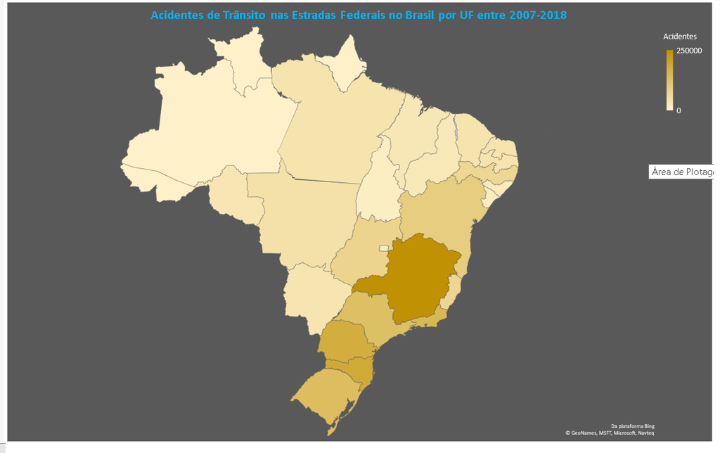

## 3 - Acidentes ocorridos em estradas Federais no Estado de Goiás

Nesta seção selecionamos todas as estradas federais no Estado de Goiás que no período de 2007 até 2018 somaram mais de 3000 acidentes.

```r
prf_acidentes_go <- subset(prf_acidentes, prf_acidentes$uf == "GO" & (prf_acidentes$br == '153' | prf_acidentes$br == '20' | prf_acidentes$br == '364' | prf_acidentes$br == '40' | prf_acidentes$br == '50' | prf_acidentes$br == '60' | prf_acidentes$br == '70' ))
```

### Tabela 3.1 - Número de acidentes por estrada federal em Goiás por ano

```r
pander(table(prf_acidentes_go$br, prf_acidentes_go$ano))
```

Table continues below

|  | 2007 | 2008 | 2009 | 2010 | 2011 | 2012 | 2013 | 2014 | 2015 | 2016 |
| --- | --- | --- | --- | --- | --- | --- | --- | --- | --- | --- |
| **153** | 1926 | 2349 | 2492 | 2754 | 2811 | 2620 | 2649 | 2490 | 2051 | 1478 |
| **20** | 248 | 284 | 328 | 394 | 406 | 449 | 432 | 419 | 264 | 237 |
| **364** | 337 | 397 | 383 | 379 | 400 | 340 | 364 | 296 | 239 | 211 |
| **40** | 726 | 622 | 771 | 1061 | 1039 | 856 | 861 | 670 | 679 | 600 |
| **50** | 229 | 274 | 306 | 272 | 300 | 268 | 338 | 345 | 371 | 250 |
| **60** | 1472 | 1785 | 2079 | 2151 | 2048 | 1946 | 2203 | 1949 | 1729 | 1527 |
| **70** | 290 | 262 | 274 | 277 | 291 | 337 | 384 | 230 | 231 | 205 |

|  | 2017 | 2018 |
| --- | --- | --- |
| **153** | 1306 | 723 |
| **20** | 243 | 107 |
| **364** | 148 | 79 |
| **40** | 613 | 320 |
| **50** | 214 | 131 |
| **60** | 1283 | 642 |
| **70** | 212 | 89 |

### Tabela 3.2 - Número de acidentes em Goiás por hora do dia por ano

```r
prf_acidentes_go$horas <- substr(prf_acidentes_go$horario, start = 1, stop = 2)
pander(table(prf_acidentes_go$horas, prf_acidentes_go$ano))
```

Table continues below

|  | 2007 | 2008 | 2009 | 2010 | 2011 | 2012 | 2013 | 2014 | 2015 | 2016 |
| --- | --- | --- | --- | --- | --- | --- | --- | --- | --- | --- |
| **00** | 128 | 126 | 97 | 117 | 111 | 117 | 98 | 78 | 110 | 83 |
| **01** | 108 | 104 | 88 | 101 | 124 | 112 | 80 | 81 | 86 | 71 |
| **02** | 87 | 86 | 103 | 88 | 108 | 68 | 85 | 74 | 103 | 51 |
| **03** | 85 | 83 | 75 | 103 | 91 | 75 | 78 | 68 | 92 | 66 |
| **04** | 97 | 104 | 111 | 119 | 120 | 99 | 100 | 100 | 88 | 90 |
| **05** | 133 | 164 | 164 | 190 | 170 | 169 | 195 | 189 | 152 | 139 |
| **06** | 166 | 183 | 238 | 271 | 250 | 231 | 248 | 225 | 210 | 189 |
| **07** | 238 | 270 | 342 | 375 | 399 | 413 | 442 | 371 | 282 | 247 |
| **08** | 210 | 271 | 280 | 342 | 365 | 309 | 396 | 329 | 227 | 218 |
| **09** | 172 | 241 | 270 | 290 | 337 | 311 | 325 | 273 | 217 | 207 |
| **10** | 203 | 258 | 307 | 346 | 298 | 291 | 320 | 281 | 287 | 170 |
| **11** | 209 | 245 | 279 | 312 | 317 | 323 | 339 | 302 | 238 | 169 |
| **12** | 187 | 224 | 267 | 300 | 297 | 235 | 285 | 268 | 236 | 177 |
| **13** | 218 | 262 | 307 | 311 | 349 | 314 | 344 | 304 | 219 | 208 |
| **14** | 249 | 335 | 376 | 384 | 434 | 347 | 393 | 391 | 308 | 218 |
| **15** | 317 | 371 | 463 | 428 | 461 | 445 | 468 | 473 | 356 | 261 |
| **16** | 317 | 418 | 446 | 497 | 482 | 481 | 536 | 474 | 399 | 301 |
| **17** | 393 | 409 | 513 | 525 | 513 | 580 | 567 | 484 | 418 | 334 |
| **18** | 407 | 462 | 532 | 556 | 570 | 545 | 592 | 485 | 401 | 342 |
| **19** | 387 | 437 | 428 | 509 | 469 | 375 | 411 | 373 | 355 | 305 |
| **20** | 272 | 342 | 304 | 373 | 357 | 308 | 291 | 240 | 256 | 231 |
| **21** | 249 | 236 | 251 | 292 | 279 | 269 | 257 | 207 | 215 | 150 |
| **22** | 205 | 206 | 212 | 246 | 226 | 235 | 214 | 179 | 175 | 168 |
| **23** | 191 | 136 | 180 | 213 | 168 | 164 | 167 | 150 | 134 | 113 |

|  | 2017 | 2018 |
| --- | --- | --- |
| **00** | 92 | 39 |
| **01** | 81 | 33 |
| **02** | 64 | 40 |
| **03** | 80 | 45 |
| **04** | 66 | 39 |
| **05** | 121 | 71 |
| **06** | 180 | 81 |
| **07** | 255 | 121 |
| **08** | 160 | 103 |
| **09** | 176 | 91 |
| **10** | 128 | 75 |
| **11** | 169 | 82 |
| **12** | 172 | 91 |
| **13** | 182 | 90 |
| **14** | 200 | 104 |
| **15** | 230 | 99 |
| **16** | 254 | 113 |
| **17** | 289 | 138 |
| **18** | 290 | 165 |
| **19** | 225 | 172 |
| **20** | 183 | 105 |
| **21** | 151 | 82 |
| **22** | 142 | 59 |
| **23** | 129 | 53 |

Notamos que há um incremento de acidentes nas estradas entre 15:00 horas e 20:00 horas. Resultados corroboram com boletins da própria Polícia Rodoviária Federal.

### Tabela 3.3 - Número de acidentes por dias da semana em Goiás por ano.

```r
prf_acidentes_go$dia_semana <- revalue(prf_acidentes_go$dia_semana, c("domingo" = "Domingo", "quarta-feira" = "Quarta", "quinta-feira" = "Quinta", "sábado" = "Sábado", "segunda-feira" = "Segunda", "terça-feira" = "Terça", "sexta-feira" = "Sexta"))
prf_acidentes_go$dia_semana = factor(prf_acidentes_go$dia_semana,levels(prf_acidentes_go$dia_semana)[c(1, 5, 7, 2, 3, 6, 4)])

pander(table(prf_acidentes_go$dia_semana, prf_acidentes_go$ano))
```

Table continues below

|  | 2007 | 2008 | 2009 | 2010 | 2011 | 2012 | 2013 | 2014 | 2015 |
| --- | --- | --- | --- | --- | --- | --- | --- | --- | --- |
| **Domingo** | 894 | 958 | 1041 | 1231 | 1165 | 1098 | 1130 | 985 | 873 |
| **Quinta** | 696 | 795 | 873 | 935 | 990 | 922 | 981 | 804 | 745 |
| **Sábado** | 904 | 967 | 1090 | 1234 | 1201 | 1033 | 1125 | 1052 | 926 |
| **Segunda** | 718 | 777 | 925 | 951 | 980 | 969 | 980 | 856 | 750 |
| **Terça** | 643 | 747 | 785 | 840 | 890 | 894 | 886 | 781 | 711 |
| **Sexta** | 756 | 952 | 1043 | 1140 | 1152 | 1083 | 1167 | 1055 | 855 |
| **Quarta** | 617 | 777 | 876 | 957 | 917 | 817 | 962 | 866 | 704 |

|  | 2016 | 2017 | 2018 |
| --- | --- | --- | --- |
| **Domingo** | 724 | 668 | 360 |
| **Quinta** | 618 | 528 | 277 |
| **Sábado** | 745 | 686 | 336 |
| **Segunda** | 593 | 556 | 287 |
| **Terça** | 545 | 436 | 272 |
| **Sexta** | 709 | 621 | 309 |
| **Quarta** | 574 | 524 | 250 |

### Tabebela 3.4 - Número de acidentes por tipo de pista em Goiás por ano

```r
prf_acidentes_go$tipo_pista <- revalue(prf_acidentes_go$tipo_pista, c("Dupla               " = "Dupla", "Múltipla            " = "Múltipla", "Simples             " = "Simples"))
tabela <- table(prf_acidentes_go$tipo_pista, prf_acidentes_go$ano)
tabela <- tabela[1:3,]
pander(tabela)
```

Table continues below

|  | 2007 | 2008 | 2009 | 2010 | 2011 | 2012 | 2013 | 2014 | 2015 |
| --- | --- | --- | --- | --- | --- | --- | --- | --- | --- |
| **Dupla** | 2612 | 3041 | 3505 | 3817 | 3908 | 3623 | 4218 | 3799 | 3561 |
| **Múltipla** | 69 | 100 | 60 | 166 | 198 | 237 | 266 | 264 | 213 |
| **Simples** | 2547 | 2832 | 3068 | 3305 | 3188 | 2956 | 2747 | 2336 | 1790 |

|  | 2016 | 2017 | 2018 |
| --- | --- | --- | --- |
| **Dupla** | 3077 | 2731 | 1424 |
| **Múltipla** | 132 | 136 | 88 |
| **Simples** | 1299 | 1152 | 579 |

### Tabela 3.5 Número de acidentes por tipo de estrada em Goiás para cada estrada seleciona por ano do acidente

```r
tabela <- xtabs(~ br + tipo_pista + ano, prf_acidentes_go)
pander(tabela[1:7, 1:3, 1:12])
```

Table continues below

|  |  | ano | 2007 | 2008 | 2009 | 2010 | 2011 | 2012 | 2013 | 2014 |
| --- | --- | --- | --- | --- | --- | --- | --- | --- | --- | --- |
| br | tipo_pista |  |  |  |  |  |  |  |  |  |
| 153 | Dupla |  | 1150 | 1450 | 1608 | 1581 | 1742 | 1583 | 1566 | 1507 |
|  | Múltipla |  | 56 | 67 | 30 | 147 | 148 | 187 | 205 | 193 |
|  | Simples |  | 720 | 832 | 854 | 1026 | 921 | 850 | 878 | 790 |
| 20 | Dupla |  | 36 | 24 | 20 | 27 | 25 | 31 | 16 | 15 |
|  | Múltipla |  | 0 | 4 | 2 | 0 | 2 | 3 | 1 | 1 |
|  | Simples |  | 212 | 256 | 306 | 367 | 379 | 415 | 415 | 403 |
| 364 | Dupla |  | 54 | 69 | 48 | 59 | 71 | 69 | 64 | 55 |
|  | Múltipla |  | 5 | 4 | 6 | 0 | 0 | 1 | 1 | 0 |
|  | Simples |  | 278 | 324 | 329 | 320 | 329 | 270 | 299 | 241 |
| 40 | Dupla |  | 556 | 492 | 610 | 876 | 821 | 624 | 621 | 445 |
|  | Múltipla |  | 0 | 0 | 2 | 1 | 1 | 3 | 3 | 3 |
|  | Simples |  | 170 | 130 | 159 | 184 | 217 | 229 | 237 | 222 |
| 50 | Dupla |  | 10 | 8 | 4 | 14 | 14 | 13 | 12 | 12 |
|  | Múltipla |  | 1 | 3 | 1 | 0 | 0 | 3 | 2 | 0 |
|  | Simples |  | 218 | 263 | 301 | 258 | 286 | 252 | 324 | 333 |
| 60 | Dupla |  | 771 | 979 | 1183 | 1171 | 1068 | 1118 | 1685 | 1654 |
|  | Múltipla |  | 7 | 22 | 19 | 14 | 12 | 17 | 36 | 42 |
|  | Simples |  | 694 | 784 | 877 | 966 | 968 | 811 | 482 | 253 |
| 70 | Dupla |  | 35 | 19 | 32 | 89 | 167 | 185 | 254 | 111 |
|  | Múltipla |  | 0 | 0 | 0 | 4 | 35 | 23 | 18 | 25 |
|  | Simples |  | 255 | 243 | 242 | 184 | 88 | 129 | 112 | 94 |

| 2015 | 2016 | 2017 | 2018 |
| --- | --- | --- | --- |
| 1238 | 946 | 807 | 436 |
| 155 | 75 | 82 | 62 |
| 658 | 457 | 417 | 225 |
| 14 | 14 | 18 | 13 |
| 0 | 0 | 2 | 0 |
| 250 | 223 | 223 | 94 |
| 54 | 26 | 24 | 15 |
| 4 | 4 | 0 | 0 |
| 181 | 181 | 124 | 64 |
| 506 | 480 | 472 | 261 |
| 4 | 4 | 0 | 1 |
| 169 | 116 | 141 | 58 |
| 42 | 45 | 84 | 64 |
| 1 | 2 | 0 | 0 |
| 328 | 203 | 130 | 67 |
| 1590 | 1431 | 1192 | 585 |
| 39 | 41 | 47 | 23 |
| 100 | 55 | 44 | 34 |
| 117 | 135 | 134 | 50 |
| 10 | 6 | 5 | 2 |
| 104 | 64 | 73 | 37 |

## 3.6 - Acidentes por tipo de estrada nas estradas goiânas por ano

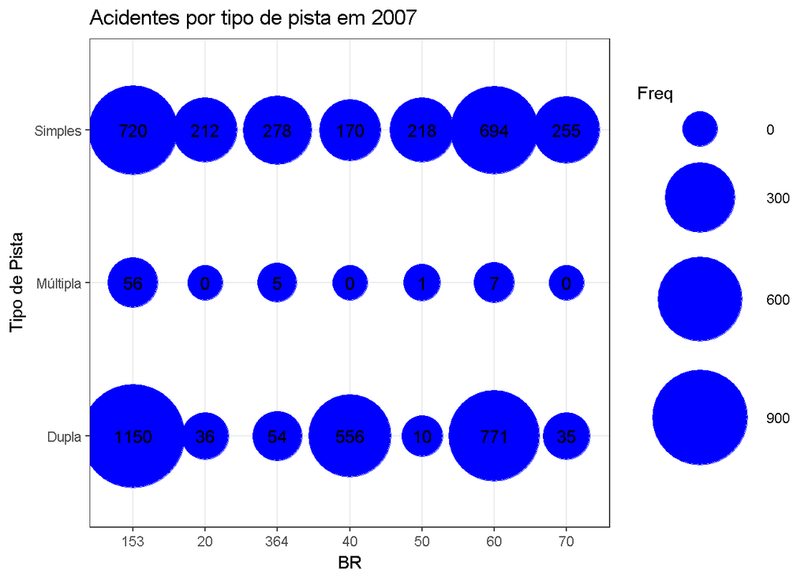

```r
library(ggplot2)
tabela <- as.data.frame(tabela)
tabela <- tabela[tabela$tipo_pista != '(null)',]
tabela <- tabela[-c(22:28, 50:56, 78:84, 106:112, 134:140, 162:168, 190:196, 218:224, 246:250),]


g1 <- ggplot(tabela[tabela$ano == '2007',], aes(br, tipo_pista)) + geom_point(aes(size = Freq), colour = "blue") + theme_bw() + ggtitle("Acidentes por tipo de pista em 2007") + xlab("BR") + ylab("Tipo de Pista") + scale_size_continuous(range=c(10,30)) + geom_text(aes(label = Freq))
g1
```

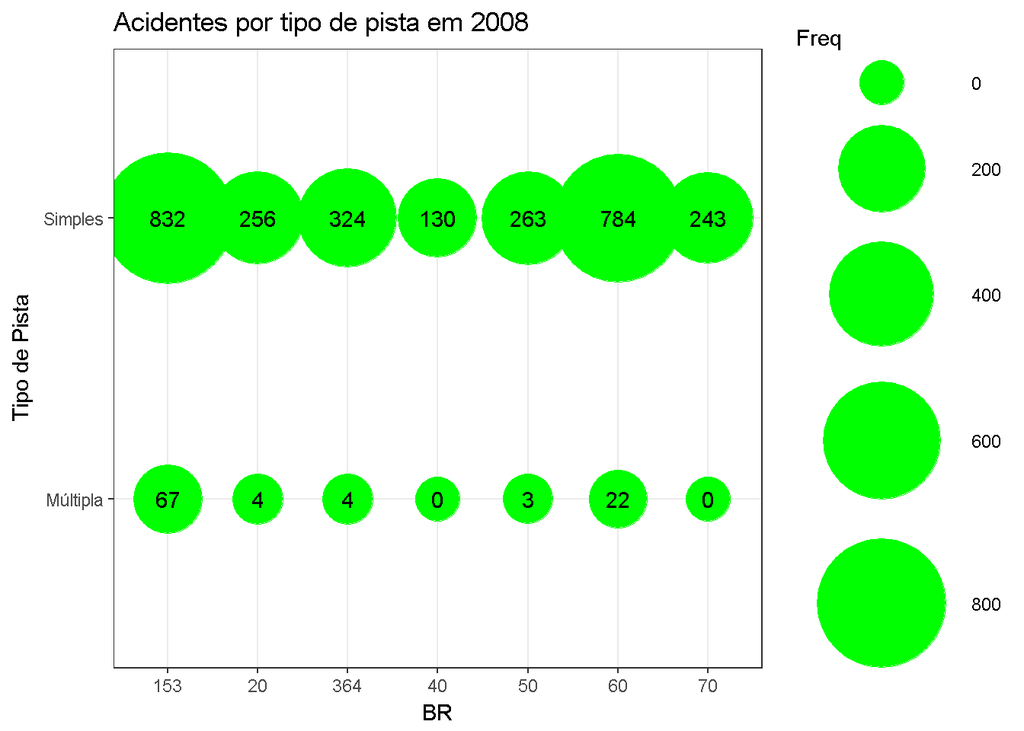

```r
g2 <- ggplot(tabela[tabela$ano == '2008',], aes(br, tipo_pista)) + geom_point(aes(size = Freq), colour = "green") + theme_bw() + ggtitle("Acidentes por tipo de pista em 2008") + xlab("BR") + ylab("Tipo de Pista") + scale_size_continuous(range=c(10,30)) + geom_text(aes(label = Freq))
g2
```

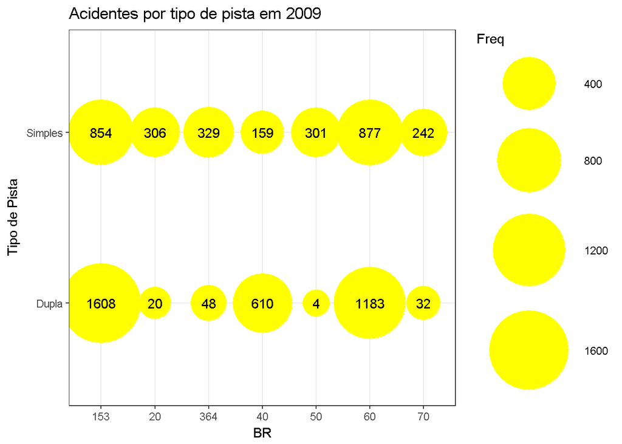

```r
g3 <- ggplot(tabela[tabela$ano == '2009',], aes(br, tipo_pista)) + geom_point(aes(size = Freq), colour = "yellow") + theme_bw() + ggtitle("Acidentes por tipo de pista em 2009") + xlab("BR") + ylab("Tipo de Pista") + scale_size_continuous(range=c(10,30)) + geom_text(aes(label = Freq))
g3
```

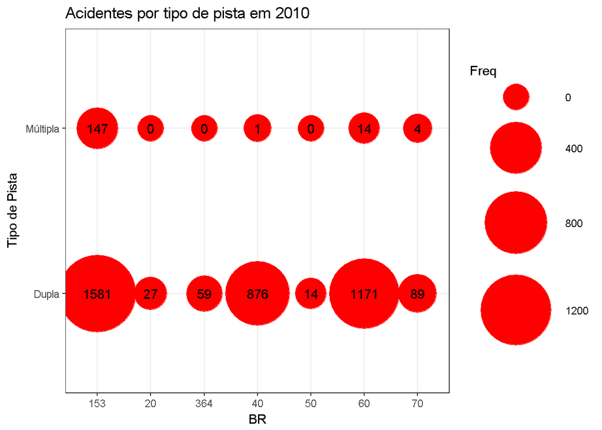

```r
g4 <- ggplot(tabela[tabela$ano == '2010',], aes(br, tipo_pista)) + geom_point(aes(size = Freq), colour = "red") + theme_bw() + ggtitle("Acidentes por tipo de pista em 2010") + xlab("BR") + ylab("Tipo de Pista") + scale_size_continuous(range=c(10,30)) + geom_text(aes(label = Freq))
g4
```

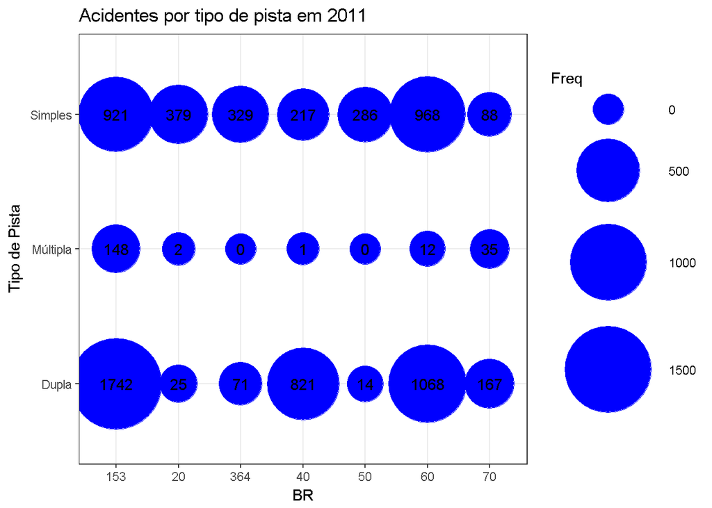

```r
g5 <- ggplot(tabela[tabela$ano == '2011',], aes(br, tipo_pista)) + geom_point(aes(size = Freq), colour = "blue") + theme_bw() + ggtitle("Acidentes por tipo de pista em 2011") + xlab("BR") + ylab("Tipo de Pista") + scale_size_continuous(range=c(10,30)) + geom_text(aes(label = Freq))
g5
```

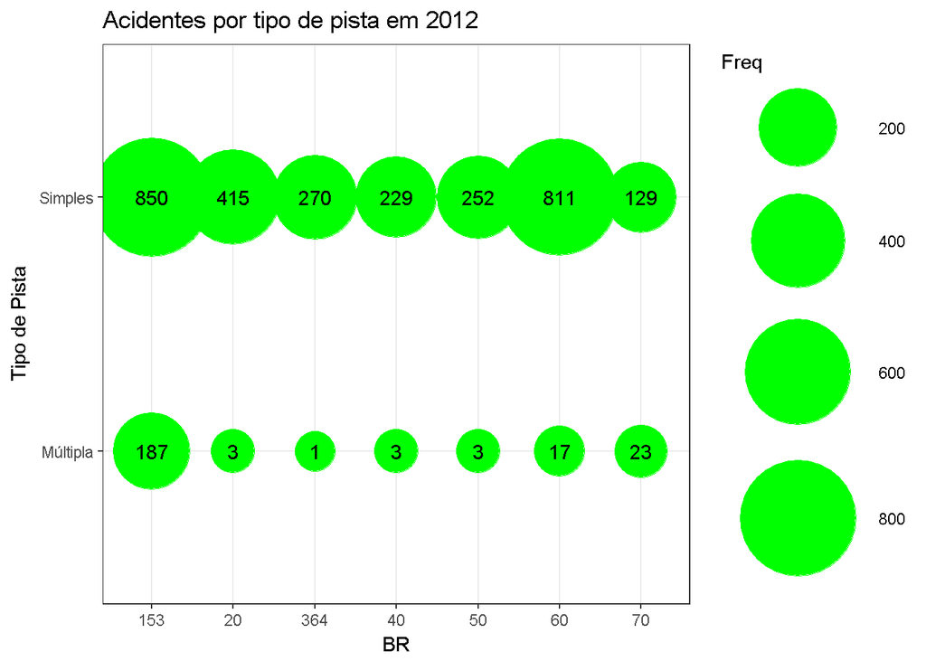

```r
g6 <- ggplot(tabela[tabela$ano == '2012',], aes(br, tipo_pista)) + geom_point(aes(size = Freq), colour = "green") + theme_bw() + ggtitle("Acidentes por tipo de pista em 2012") + xlab("BR") + ylab("Tipo de Pista") + scale_size_continuous(range=c(10,30)) + geom_text(aes(label = Freq))
g6
```

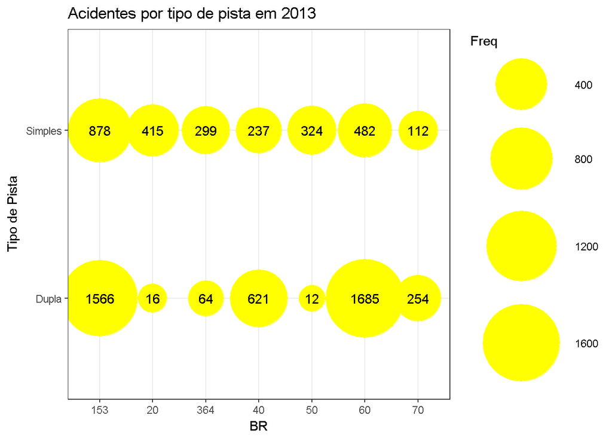

```r
g7 <- ggplot(tabela[tabela$ano == '2013',], aes(br, tipo_pista)) + geom_point(aes(size = Freq), colour = "yellow") + theme_bw() + ggtitle("Acidentes por tipo de pista em 2013") + xlab("BR") + ylab("Tipo de Pista") + scale_size_continuous(range=c(10,30)) + geom_text(aes(label = Freq))
g7
```

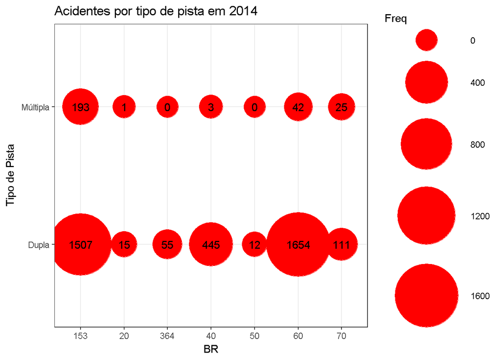

```r
g8 <- ggplot(tabela[tabela$ano == '2014',], aes(br, tipo_pista)) + geom_point(aes(size = Freq), colour = "red") + theme_bw() + ggtitle("Acidentes por tipo de pista em 2014") + xlab("BR") + ylab("Tipo de Pista") + scale_size_continuous(range=c(10,30)) + geom_text(aes(label = Freq))
g8
```

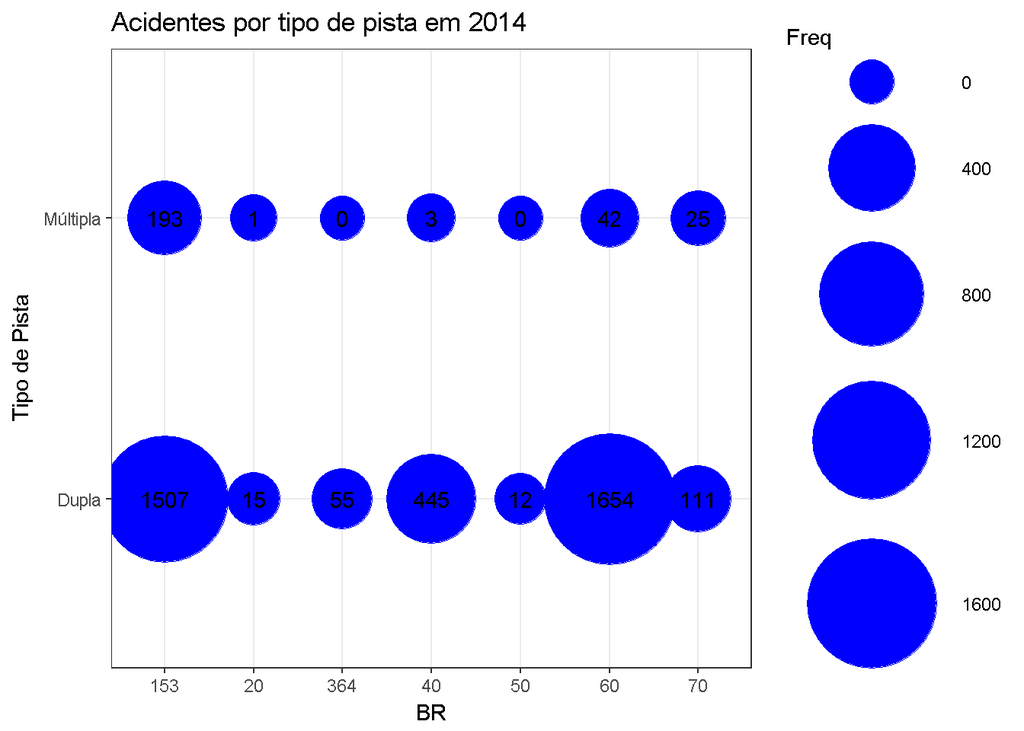

```r
g9 <- ggplot(tabela[tabela$ano == '2014',], aes(br, tipo_pista)) + geom_point(aes(size = Freq), colour = "blue") + theme_bw() + ggtitle("Acidentes por tipo de pista em 2014") + xlab("BR") + ylab("Tipo de Pista") + scale_size_continuous(range=c(10,30)) + geom_text(aes(label = Freq))
g9
```

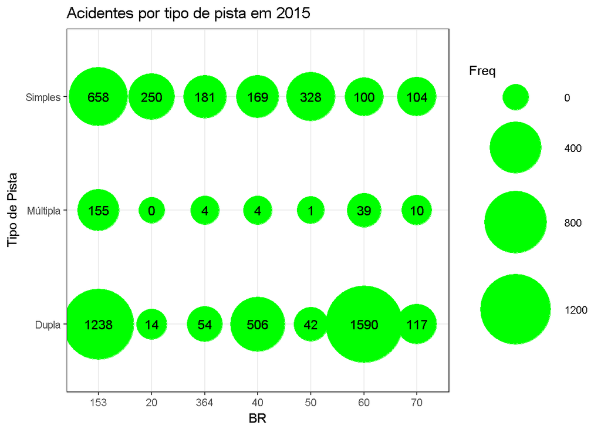

```r
g10 <- ggplot(tabela[tabela$ano == '2015',], aes(br, tipo_pista)) + geom_point(aes(size = Freq), colour = "green") + theme_bw() + ggtitle("Acidentes por tipo de pista em 2015") + xlab("BR") + ylab("Tipo de Pista") + scale_size_continuous(range=c(10,30)) + geom_text(aes(label = Freq))
g10
```

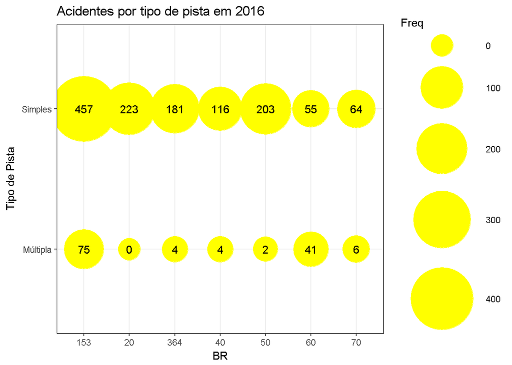

```r
g11 <- ggplot(tabela[tabela$ano == '2016',], aes(br, tipo_pista)) + geom_point(aes(size = Freq), colour = "yellow") + theme_bw() + ggtitle("Acidentes por tipo de pista em 2016") + xlab("BR") + ylab("Tipo de Pista") + scale_size_continuous(range=c(10,30)) + geom_text(aes(label = Freq))
g11
```

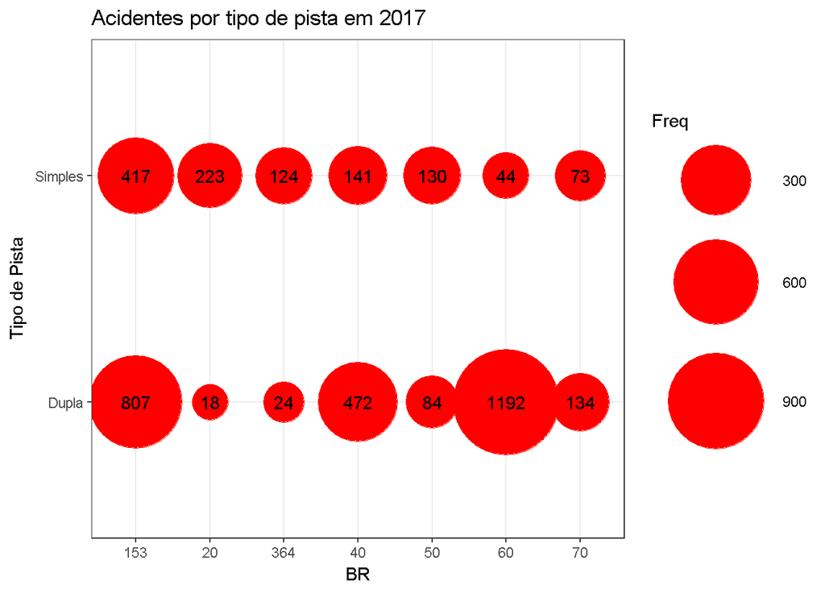

```r
g12 <- ggplot(tabela[tabela$ano == '2017',], aes(br, tipo_pista)) + geom_point(aes(size = Freq), colour = "red") + theme_bw() + ggtitle("Acidentes por tipo de pista em 2017") + xlab("BR") + ylab("Tipo de Pista") + scale_size_continuous(range=c(10,30)) + geom_text(aes(label = Freq))
g12
```

```r
rm(g1, g2, g3, g4, g5, g6, g7, g8, g9, g10,g11,g12)
```

## 3.7 - Acidentes por tipo de estrada entre 2007-2017 nas estradas goiânas

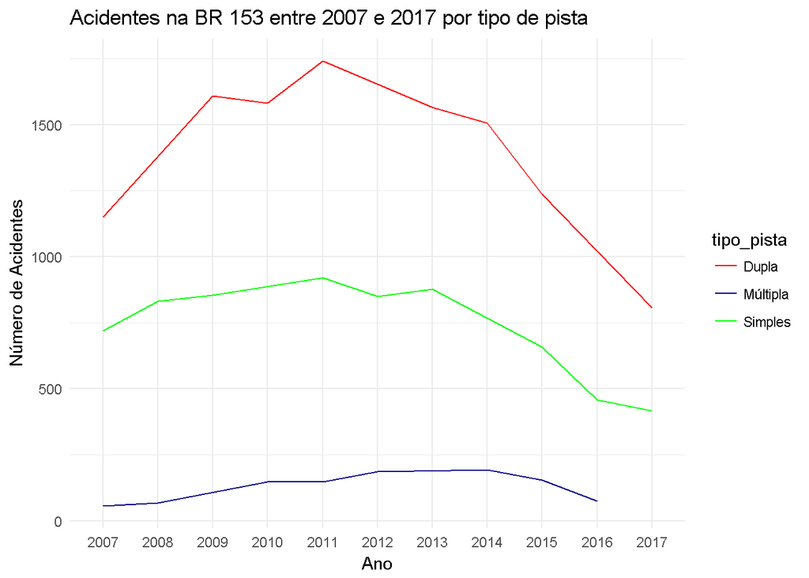

```r
p1 <- ggplot(tabela[tabela$br == '153' & tabela$ano != '2018',], aes(x=ano, y=Freq, group=tipo_pista)) +
    geom_line(aes(colour = tipo_pista)) + ggtitle("Acidentes na BR 153 entre 2007 e 2017 por tipo de pista") + xlab("Ano") + ylab("Número de Acidentes") + theme_minimal()
p1+scale_color_manual(values=c("#FF0000", "#00008B", "#00FF00"))
```

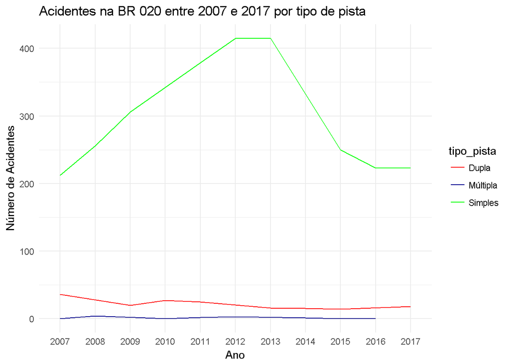

```r
p2 <- ggplot(tabela[tabela$br == '20' & tabela$ano != '2018',], aes(x=ano, y=Freq, group=tipo_pista)) +
    geom_line(aes(colour = tipo_pista)) + ggtitle("Acidentes na BR 020 entre 2007 e 2017 por tipo de pista") + xlab("Ano") + ylab("Número de Acidentes") + theme_minimal()
p2+scale_color_manual(values=c("#FF0000", "#00008B", "#00FF00"))
```

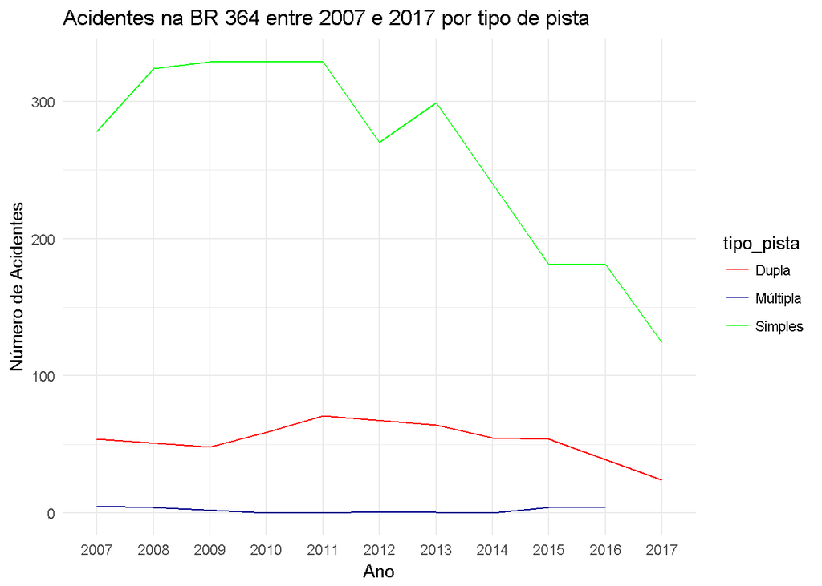

```r
p3 <- ggplot(tabela[tabela$br == '364' & tabela$ano != '2018',], aes(x=ano, y=Freq, group=tipo_pista)) +
    geom_line(aes(colour = tipo_pista)) + ggtitle("Acidentes na BR 364 entre 2007 e 2017 por tipo de pista") + xlab("Ano") + ylab("Número de Acidentes") + theme_minimal()
p3+scale_color_manual(values=c("#FF0000", "#00008B", "#00FF00"))
```

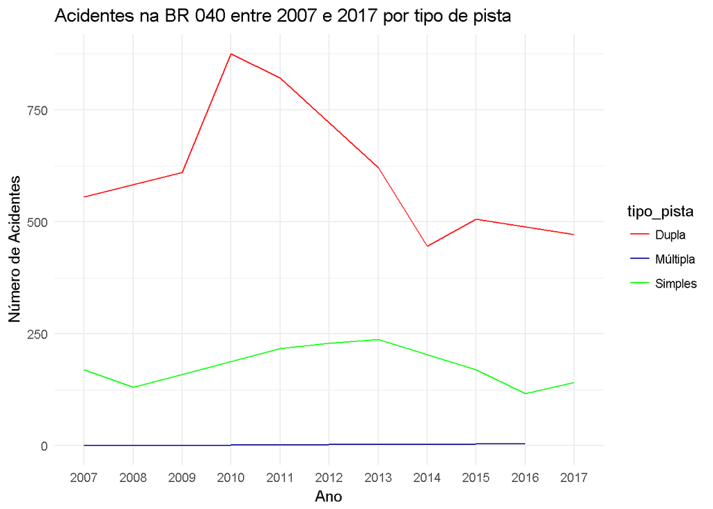

```r
p4 <- ggplot(tabela[tabela$br == '40' & tabela$ano != '2018',], aes(x=ano, y=Freq, group=tipo_pista)) +
    geom_line(aes(colour = tipo_pista)) + ggtitle("Acidentes na BR 040 entre 2007 e 2017 por tipo de pista") + xlab("Ano") + ylab("Número de Acidentes") + theme_minimal()
p4+scale_color_manual(values=c("#FF0000", "#00008B", "#00FF00"))
```